# AI-Enabled Research Bootcamp: results brief

AI-Enabled Research Bootcamp

Results brief · October 1–8, 2026 · Led by Impact Analytics (Development Impact) with the Development Data Group and ITS

[figure not shown]

**98 staff. 5 days. Agentic AI tools installed on every participant's computer.** In the first-ever AI-Enabled Research Bootcamp, participants learned by doing, working with coding agents, memory files, and reusable skills across the research cycle, with instructors in the room throughout to provide customized support. Participant feedback was overwhelmingly positive. Here is where participants started, where they got to, and what comes next.

[output not shown]

<sup>1</sup> Rated 4 or 5 on a 5-point scale (3 = met expectations); 51% gave a 5. Results from feedback survey (49% response rate).

Who attended

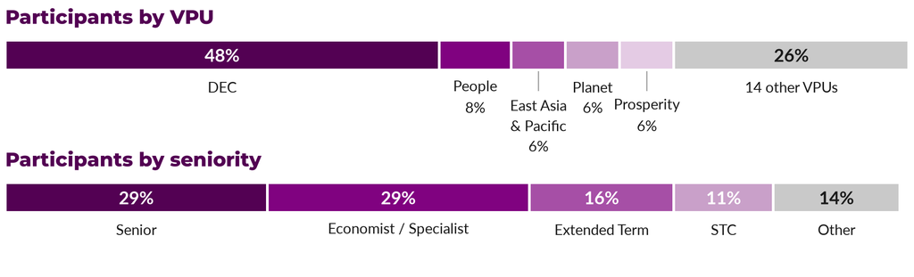

Where participants started

Nearly all participants (98%) already used AI at work, but mostly as a chat assistant for writing and background research. Few had used the tools the Bootcamp focused on<sup>2</sup>:

| 24% had ever used a coding agent |  | 26% had created an AI memory file |  | 27% had used a reusable AI skill |
| --- | --- | --- | --- | --- |

<sup>2</sup> Baseline survey: 63 of 98 responded. It measures prior use and the end-of-course survey measures confidence, so they are not directly comparable.

What participants gained

After the week, 83% felt confident directing an AI agent, and participants expect to use about 70% of the content.

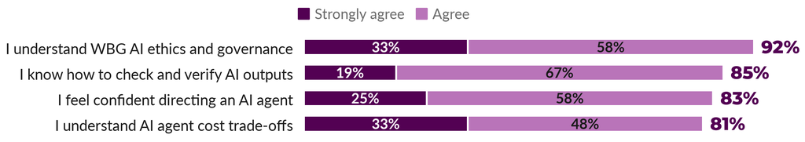

In participants' words

[output not shown]

[output not shown]

Quotes are from anonymous survey responses; [...] marks omitted text, and obvious typos were corrected.

Next steps